# Selección de variables

La selección de variables es un proceso en el que se escogen automáticamente las características de los datos que más contribuyen a la variable objetivo.

La presencia de variables irrelevantes en los datos puede reducir la precisión de algunos modelos, especialmente los algoritmos lineales como la regresión lineal y logística.

- Reduce el sobreajuste y Mejora la precisión en algunos modelos. En algunos casos, menos datos redundantes significa menos oportunidades de tomar decisiones basadas en el ruido.
- Reduce el tiempo de entrenamiento: Menos datos significa que los algoritmos se entrenan más rápido.

### Importo las librerías

```python
import pandas as pd
import numpy as np
import sklearn
from sklearn.pipeline import Pipeline
from sklearn import metrics
# conda install category_encoders
import category_encoders as ce
from sklearn.preprocessing import OneHotEncoder

import matplotlib.pyplot as plt
import seaborn as sns
from sklearn.ensemble import RandomForestClassifier, GradientBoostingClassifier
from sklearn import metrics
from sklearn.metrics import plot_confusion_matrix, roc_curve, roc_auc_score
from sklearn.linear_model import Lasso, LogisticRegression
from sklearn.feature_selection import SelectFromModel, RFE
from sklearn.preprocessing import StandardScaler
from sklearn.tree import DecisionTreeClassifier

from boruta import BorutaPy # !conda install -c conda-forge boruta_py
```

## Lectura del dataset: train y test

```python
pd_loan_train = pd.read_csv("./data_preprocessing/train_pd_data_preprocessing_missing_outlier.csv")\
                  .set_index(['id', 'url', 'zip_code'])
pd_loan_test = pd.read_csv("./data_preprocessing/test_pd_data_preprocessing_missing_outlier.csv")\
                  .set_index(['id', 'url', 'zip_code'])
```

```python
pd_loan_train.columns
```

```
Index(['grade', 'home_ownership', 'verification_status', 'initial_list_status',
       'purpose', 'addr_state', 'application_type', 'loan_status',
       'total_acc_input', 'fico_range_high_input',
       'mo_sin_old_rev_tl_op_input', 'pub_rec_bankruptcies_input',
       'sub_grade_input', 'mths_since_last_record_input', 'loan_amnt_input',
       'earliest_cr_line_month_input', 'mo_sin_old_il_acct_input',
       'installment_input', 'earliest_cr_line_year_input', 'term_input',
       'mths_since_recent_revol_delinq_input', 'mths_since_last_delinq_input',
       'fico_range_low_input', 'mths_since_last_major_derog_input',
       'revol_util_input', 'mths_since_recent_bc_dlq_input', 'dti_input',
       'emp_length_input', 'open_acc_input', 'pub_rec_input',
       'annual_inc_input', 'mort_acc_input', 'int_rate_input'],
      dtype='object')
```

## Codificación de la variable objetivo y del resto de variables categoricas

1: Charged off

0: Fully Paid

```python
print(pd_loan_train['loan_status'].value_counts())
pd_loan_train['loan_status'] = pd_loan_train['loan_status']\
                                .map({'Fully Paid': 0, 'Charged Off': 1}).astype(int)

pd_loan_test['loan_status'] = pd_loan_test['loan_status']\
                                .map({'Fully Paid': 0, 'Charged Off': 1}).astype(int)
```

```
Fully Paid     276416
Charged Off     77637
Name: loan_status, dtype: int64
```

```python
X_train = pd_loan_train.drop('loan_status',axis=1)
X_test = pd_loan_test.drop('loan_status',axis=1)
y_train = pd_loan_train['loan_status']
y_test = pd_loan_test['loan_status']
```

Por ejemplo, elijo codificarlas con one-hot-encoding todas. Se podría elegir codificar algunas de una forma y otras de otra. Por ejemplo, variables con pocas categorías con one hot encoding y variables con más categorias con TargetEncoding

```python
list_columns_cat = list(X_train.select_dtypes("object", "category").columns)
list_other = list(set(X_train.columns)-set(list_columns_cat))
ohe = ce.OneHotEncoder(cols=list_columns_cat)
model = ohe.fit(X_train, y_train)
```

```python
X_train_t = model.transform(X_train, y_train)
X_test_t = model.transform(X_test, y_test)
len(list(X_train_t.columns))
```

```
108
```

Es posible que para la variable addr_state vaya mejor un TargetEncoding o un Catboost encoder. Se pueden probar diferentes posibilidades

## Escalado de las variables

En algunos algoritmos no es necesario estandarizar variables, aunque no pasa nada si se hace. Probad

https://scikit-learn.org/stable/modules/generated/sklearn.preprocessing.StandardScaler.html

```python
scaler = StandardScaler()
model_scaled = scaler.fit(X_train_t)
X_train_scaled = pd.DataFrame(scaler.transform(X_train_t), columns=X_train_t.columns, index=X_train_t.index)
X_test_scaled = pd.DataFrame(scaler.transform(X_test_t), columns=X_test_t.columns, index=X_test.index)
```

## Métodos de elección de las variables más importantes

https://scikit-learn.org/stable/modules/generated/sklearn.feature_selection.SelectFromModel.html

## 1. SelectFromModel

SelectFromModel es una función que puede utilizarse junto con cualquier estimador que asigne importancia a cada variable a través de un atributo específico (como coef_, feature*importances*). Las características que se consideran "poco importantes", se eliminan. Si la importancia correspondiente de los valores de las características está por debajo del parámetro de umbral proporcionado. Aparte de especificar el umbral numéricamente, existen heurísticas incorporadas para encontrar un umbral utilizando un argumento de cadena. Las heurísticas disponibles son "media", "mediana" y múltiplos flotantes de éstas, como "0,1*media". En combinación con el criterio del umbral, se puede utilizar el parámetro max_features para establecer un límite en el número de características a seleccionar.

https://scikit-learn.org/stable/modules/feature_selection.html

El inconveniente de este método es que tú mismo tienes que elegir el threshold a partir del cual eliges las "n" primeras variables

### * Regresiones con regularización

Las estrategias de regularización incorporan penalizaciones en el ajuste por mínimos cuadrados ordinarios (OLS) con el objetivo de evitar overfitting, reducir varianza, atenuar el efecto de la correlación entre predictores y minimizar la influencia en el modelo de los predictores menos relevantes. Por lo general, aplicando regularización se consigue modelos con mayor poder predictivo (generalización).

Dado que estos métodos de regularización actúan sobre la magnitud de los coeficientes del modelo, todos deben de estár en la misma escala, por esta razón es necesario estandarizar o normalizar los predictores antes de entrenar el modelo.

### - Regularización Ridge

La regularización Ridge penaliza la suma de los coeficientes estimados elevados al cuadrado A esta penalización se le conoce como l2 y tiene el efecto de reducir de forma proporcional el valor de todos los coeficientes del modelo pero sin que estos lleguen a cero.

El grado de penalización está controlado por el hiperparámetro λ . Cuando λ=0 , la penalización es nula y el resultado es equivalente al de un modelo lineal por mínimos cuadrados ordinarios (OLS). A medida que λ aumenta, mayor es la penalización y menor el valor de los predictores.

```python
sel_ridge = SelectFromModel(LogisticRegression(C=1, penalty='l2'), threshold = 1e-4)
sel_ridge.fit(X_train_scaled, y_train)
# Si aplicas transform(X_train_scaled, y_train) y transform(X_test_scaled, y_test), filtra las variables seleccionadas
```

[output not shown]

[figure not shown]

```python
# Coeficientes del modelo
# ==============================================================================
df_coeficientes = pd.DataFrame(
                        {'predictor': X_train_scaled.columns,
                         'coef': sel_ridge.estimator_.coef_.flatten()}
                  )

fig, ax = plt.subplots(figsize=(16, 3.84))
ax.stem(df_coeficientes.predictor, df_coeficientes.coef, markerfmt=' ')
plt.xticks(rotation=90, ha='right', size=10)
ax.set_xlabel('variable')
ax.set_ylabel('coeficientes')
ax.set_title('Coeficientes del modelo ridge');
```

```python
sel_ridge.get_support()
selected_feat = X_train_scaled.columns[sel_ridge.get_support()]
selected_feat
```

```
Index(['grade_1', 'grade_2', 'grade_3', 'grade_4', 'grade_5', 'grade_6',
       'grade_7', 'fico_range_high_input', 'mo_sin_old_rev_tl_op_input',
       'sub_grade_input', 'loan_amnt_input', 'installment_input',
       'earliest_cr_line_year_input', 'term_input', 'fico_range_low_input',
       'dti_input', 'emp_length_input', 'open_acc_input', 'annual_inc_input',
       'mort_acc_input', 'int_rate_input'],
      dtype='object')
```

```python
print('total features: {}'.format((X_train_scaled.shape[1])))
print('selected features: {}'.format(len(selected_feat)))
```

```
total features: 108
selected features: 21
```

### - Regularización Lasso

La regresion lasso (penalización L1) acepta coeficientes que sean 0. En la función SelectFromModel si no se especifican parámetros, en este caso se queda con todas las variables cuyo coeficiente no sea cero. Para limitar el número de variables es necesario poner valor a los parámetros

```python
sel_lasso = SelectFromModel(LogisticRegression(C=1, penalty='l1',
                                          solver='liblinear'), threshold = 0.08) # jugar con el threshold
sel_lasso.fit(X_train_scaled, y_train)
```

```
SelectFromModel(estimator=LogisticRegression(C=1, penalty='l1',
                                             solver='liblinear'),
                threshold=0.08)
```

```python
sel_lasso.get_support()
selected_feat_lasso = X_train_scaled.columns[sel_lasso.get_support()]
selected_feat_lasso
```

```
Index(['grade_2', 'grade_3', 'grade_4', 'grade_5', 'grade_6', 'grade_7',
       'home_ownership_2', 'mo_sin_old_rev_tl_op_input', 'sub_grade_input',
       'loan_amnt_input', 'installment_input', 'earliest_cr_line_year_input',
       'term_input', 'fico_range_low_input', 'dti_input', 'emp_length_input',
       'open_acc_input', 'annual_inc_input', 'mort_acc_input',
       'int_rate_input'],
      dtype='object')
```

```python
print('total features: {}'.format((X_train_scaled.shape[1])))
print('selected features: {}'.format(len(selected_feat_lasso)))
```

```
total features: 108
selected features: 20
```

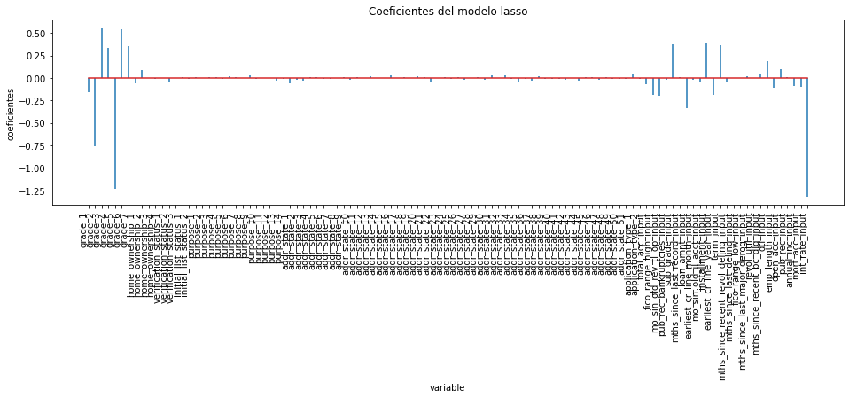

```python
# Coeficientes del modelo
# ==============================================================================
df_coeficientes_lasso = pd.DataFrame(
                        {'predictor': X_train_scaled.columns,
                         'coef': sel_lasso.estimator_.coef_.flatten()}
                  )

fig, ax = plt.subplots(figsize=(16, 3.84))
ax.stem(df_coeficientes_lasso.predictor, df_coeficientes_lasso.coef, markerfmt=' ')
plt.xticks(rotation=90, ha='right', size=10)
ax.set_xlabel('variable')
ax.set_ylabel('coeficientes')
ax.set_title('Coeficientes del modelo lasso');
```

### Comparación ridge y Lasso

La principal diferencia práctica entre lasso y ridge es que el primero consigue que algunos coeficientes sean exactamente cero, por lo que realiza selección de variables para la predicción, mientras que el segundo no llega a excluir ninguno. Esto supone una ventaja notable de lasso en escenarios donde no todos los predictores son importantes para el modelo y se desea que los menos influyentes queden excluidos.

Por otro lado, cuando existen predictores altamente correlacionados (linealmente), ridge reduce la influencia de todos ellos a la vez y de forma proporcional.

Para conseguir un equilibrio óptimo entre estas dos propiedades, se puede emplear lo que se conoce como penalización Elastic Net (https://scikit-learn.org/stable/modules/generated/sklearn.linear_model.ElasticNet.html), que combina ambas estrategias.

## 2. RFE

Dado un estimador externo que asigna pesos a las características (por ejemplo, los coeficientes de un modelo lineal), el objetivo de la eliminación recursiva de características (RFE) es seleccionarlas considerando recursivamente conjuntos cada vez más pequeños de variables. En primer lugar, el estimador se entrena con el conjunto inicial de variables y la importancia de cada una de ellas se obtiene a través de algún atributo específico. A continuación, se eliminan las características menos importantes del conjunto actual. Este procedimiento se repite recursivamente en el conjunto podado hasta que se alcanza el número deseado de características a seleccionar.

https://machinelearningmastery.com/rfe-feature-selection-in-python/

```python
# feature extraction
model = DecisionTreeClassifier()
# model = RandomForestClassifier()
rfe = RFE(model, n_features_to_select=35) #verbose=1 para ver iterativamente que pasa,
# n_features_to_select: por defecto se selecciona la mitad si no pones este parámetro , n_features_to_select=30
fit = rfe.fit(X_train_scaled, y_train)


print("Num Features: %d" % fit.n_features_)
print("Selected Features: %s" % fit.support_)
print("Feature Ranking: %s" % fit.ranking_)
```

[output not shown]

```python
print(len(X_train_scaled.columns[fit.support_]), len(X_train_scaled.columns))
```

[output not shown]

```python
X_train_scaled.columns[fit.support_]
```

## 3. Boruta

Este algoritmo suele tardar más rato que los anteriores: https://towardsdatascience.com/boruta-explained-the-way-i-wish-someone-explained-it-to-me-4489d70e154a . Iterativamente, se descolocan aleatoriamente los valores de cada columna y se ajusta un modelo. Si el resultado del modelo es el mismo habiendo descolocado aleatoriamente la columna y sin haberla descolacado, entonces la variable no aporta más información al modelo

```python
# sampling in proportion to y labels
rf = RandomForestClassifier(n_jobs=-1, max_depth=5) # cambiar los hiperparametros

# define Boruta feature selection method
feat_selector = BorutaPy(rf, n_estimators='auto', verbose=2, random_state=1)

# find all relevant features - 5 features should be selected
feat_selector.fit(X_train_t.values, y_train.values) # Importante poner el .values al dataframe, sino dará error

# check selected features - first 5 features are selected
feat_selector.support_

# check ranking of features
feat_selector.ranking_
```

[output not shown]

[output cut: 349 more lines]

```
Confirmed: 	38
Tentative: 	1
Rejected: 	69
Iteration: 	99 / 100
Confirmed: 	38
Tentative: 	1
Rejected: 	69


BorutaPy finished running.

Iteration: 	100 / 100
Confirmed: 	38
Tentative: 	0
Rejected: 	69
```

```
array([ 1,  1,  1,  1,  1,  1,  1,  1,  1,  9, 69,  1,  1,  1,  4,  4, 32,
        1,  1, 19, 14, 11, 34, 30,  1, 23, 34, 60, 69, 69,  1, 61,  2, 44,
       31, 39, 42, 42, 21, 27, 36, 38,  8, 54, 51, 13, 27, 39, 50, 23, 46,
        9, 63, 58, 55, 34, 41, 48, 29, 26, 17, 47, 18, 57,  6, 58, 25, 22,
       64, 62, 65, 53, 56, 20, 37, 48, 51, 44, 66, 69, 69, 15, 11,  1,  1,
        1,  1,  1,  1,  1, 16,  1,  1,  1,  1,  3,  1,  1,  1,  1,  6,  1,
        1,  1,  1,  1,  1,  1])
```

```python
selected_feat_boruta = X_train_scaled.columns[feat_selector.support_]
selected_feat_boruta
```

```
Index(['grade_1', 'grade_2', 'grade_3', 'grade_4', 'grade_5', 'grade_6',
       'grade_7', 'home_ownership_1', 'home_ownership_2',
       'verification_status_1', 'verification_status_2',
       'verification_status_3', 'purpose_2', 'purpose_3', 'purpose_9',
       'addr_state_1', 'total_acc_input', 'fico_range_high_input',
       'mo_sin_old_rev_tl_op_input', 'pub_rec_bankruptcies_input',
       'sub_grade_input', 'mths_since_last_record_input', 'loan_amnt_input',
       'mo_sin_old_il_acct_input', 'installment_input',
       'earliest_cr_line_year_input', 'term_input',
       'mths_since_last_delinq_input', 'fico_range_low_input',
       'mths_since_last_major_derog_input', 'revol_util_input', 'dti_input',
       'emp_length_input', 'open_acc_input', 'pub_rec_input',
       'annual_inc_input', 'mort_acc_input', 'int_rate_input'],
      dtype='object')
```

## Probar el modelo con las nuevas variables seleccionadas

```python
X_train_t = X_train_t[selected_feat_boruta]
X_test_t = X_test_t[selected_feat_boruta]
```

```python
classifiers = [
    RandomForestClassifier(),
    GradientBoostingClassifier()
    ]# estudiar los hiperparametros y usar cualquier modelo aprendido

for classifier in classifiers:
    pipe = Pipeline(steps=[('classifier', classifier)])
    pipe.fit(X_train_t, y_train)
    print(classifier)
    print("model score: %.3f" % pipe.score(X_test_t, y_test))
```

```
RandomForestClassifier()
model score: 0.786
GradientBoostingClassifier()
model score: 0.788
```

```python
clf = GradientBoostingClassifier(
              learning_rate=0.1,  max_depth=12,
              min_weight_fraction_leaf=0.02, n_estimators=130,
              random_state=2408,
              verbose=1)
clf.fit(X_train_t,y_train)
```

```
      Iter       Train Loss   Remaining Time
         1           1.0345            4.95m
         2           1.0205            4.89m
         3           1.0090            4.84m
         4           0.9995            4.81m
         5           0.9916            4.75m
         6           0.9849            4.75m
         7           0.9791            4.75m
         8           0.9740            4.75m
         9           0.9698            4.71m
        10           0.9662            4.70m
        20           0.9468            4.54m
        30           0.9395            4.39m
        40           0.9357            4.24m
        50           0.9324            3.77m
        60           0.9300            3.27m
        70           0.9281            2.80m
        80           0.9263            2.33m
        90           0.9249            1.86m
       100           0.9237            1.39m
```

```
GradientBoostingClassifier(max_depth=12, min_weight_fraction_leaf=0.02,
                           n_estimators=130, random_state=2408, verbose=1)
```

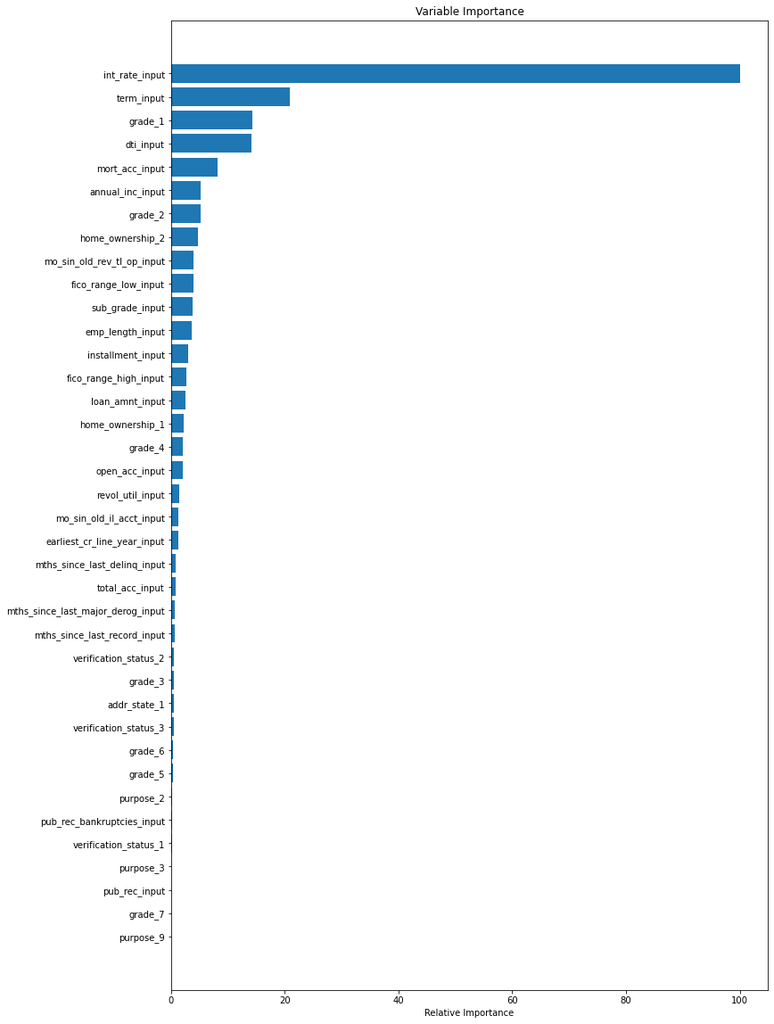

```python
feature_importance = clf.feature_importances_
# make importances relative to max importance
feature_importance = 100.0 * (feature_importance / feature_importance.max())
sorted_idx = np.argsort(feature_importance)
pos = np.arange(sorted_idx.shape[0]) + .5
# plt.subplot(1, 2, 2)
plt.figure(figsize=(12, 20))
plt.barh(pos, feature_importance[sorted_idx], align='center')
plt.yticks(pos, X_train_t.keys()[sorted_idx])
plt.xlabel('Relative Importance')
plt.title('Variable Importance')
plt.show()
```

```python
pred_test = clf.predict_proba(X_test_t)
pred_train = clf.predict_proba(X_train_t)
```

## Curva roc

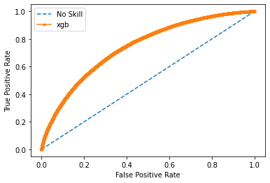

```python
# keep probabilities for the positive outcome only
yhat_train = pred_train[:, 1]
# calculate roc curves
fpr, tpr, thresholds = roc_curve(y_train, yhat_train)
# plot the roc curve for the model
plt.plot([0,1], [0,1], linestyle='--', label='No Skill')
plt.plot(fpr, tpr, marker='.', label='xgb')
# axis labels
plt.xlabel('False Positive Rate')
plt.ylabel('True Positive Rate')
plt.legend()
# show the plot
plt.show()
```

```python
# calculate AUC
auc = roc_auc_score(y_train, yhat_train)
print('AUC: %.3f' % auc)
```

```
AUC: 0.742
```

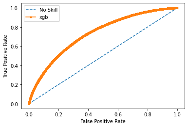

```python
# keep probabilities for the positive outcome only
yhat = pred_test[:, 1]
# calculate roc curves
fpr, tpr, thresholds = roc_curve(y_test, yhat)
# plot the roc curve for the model
plt.plot([0,1], [0,1], linestyle='--', label='No Skill')
plt.plot(fpr, tpr, marker='.', label='xgb')
# axis labels
plt.xlabel('False Positive Rate')
plt.ylabel('True Positive Rate')
plt.legend()
# show the plot
plt.show()
```

```python
# calculate AUC
auc = roc_auc_score(y_test, yhat)
print('AUC: %.3f' % auc)
```

```
AUC: 0.730
```

## Curva precision-recall

```python
# calculate pr-curve
precision, recall, thresholds = precision_recall_curve(y_test, yhat)
# plot the roc curve for the model
no_skill = len(y_test[y_test==1]) / len(y_test)
plt.plot([0,1], [no_skill,no_skill], linestyle='--', label='No Skill')
plt.plot(recall, precision, marker='.', label='Random Forest')
# axis labels
plt.xlabel('Recall')
plt.ylabel('Precision')
plt.legend()
# show the plot
plt.show()
```

[output not shown]

```python
auc_precision_recall = auc(recall, precision)
print(auc_precision_recall)
```

[output not shown]

```python
#print(metrics.classification_report(y_train.astype(float).values, pred_train[:,0].astype(float)))
#print(metrics.confusion_matrix(y_train, pred_test[:,0]))
```

Completar las metricas que faltan

```python
### Posibles ingenierias de variables
```